# STAT 689 Extended Homework 1

## 1. Consider Exercise 3.1. In these exercises display the output

### a. Issue the following commands to fit a Gaussian GAM with price as the response variable and each of the other variables as predictors

```r
library(AER)
data(HousePrices)
library(mgcv)
```

```r
fitGaussAM = mgcv::gam(price ~ s(lotsize,k = 27) + bedrooms + factor(bathrooms) + factor(stories) + factor(driveway) + factor(recreation) + factor(fullbase) + factor(gasheat) + factor(aircon) + garage + factor(prefer), data = HousePrices,family = gaussian)
summary(fitGaussAM)
```

```
##
## Family: gaussian
## Link function: identity
##
## Formula:
## price ~ s(lotsize, k = 27) + bedrooms + factor(bathrooms) + factor(stories) +
##     factor(driveway) + factor(recreation) + factor(fullbase) +
##     factor(gasheat) + factor(aircon) + garage + factor(prefer)
##
## Parametric coefficients:
##                       Estimate Std. Error t value Pr(>|t|)
## (Intercept)            35832.7     3550.2  10.093  < 2e-16 ***
## bedrooms                2102.8     1122.8   1.873 0.061638 .
## factor(bathrooms)2     13096.4     1735.0   7.548 1.95e-13 ***
## factor(bathrooms)3     29762.6     5108.0   5.827 9.84e-09 ***
## factor(bathrooms)4     68761.3    15758.7   4.363 1.54e-05 ***
## factor(stories)2        5715.0     1690.8   3.380 0.000778 ***
## factor(stories)3       12901.3     2903.8   4.443 1.08e-05 ***
## factor(stories)4       19730.6     3075.1   6.416 3.11e-10 ***
## factor(driveway)yes     5881.1     2074.3   2.835 0.004755 **
## factor(recreation)yes   3769.7     1926.7   1.957 0.050926 .
## factor(fullbase)yes     5843.3     1595.6   3.662 0.000275 ***
## factor(gasheat)yes     13018.6     3226.3   4.035 6.27e-05 ***
## factor(aircon)yes      11988.9     1582.8   7.575 1.62e-13 ***
## garage                  4097.8      852.7   4.806 2.01e-06 ***
## factor(prefer)yes       9713.8     1709.7   5.682 2.21e-08 ***
## ---
## Signif. codes:  0 '***' 0.001 '**' 0.01 '*' 0.05 '.' 0.1 ' ' 1
##
## Approximate significance of smooth terms:
##              edf Ref.df     F p-value
## s(lotsize) 3.218  4.103 24.75  <2e-16 ***
## ---
## Signif. codes:  0 '***' 0.001 '**' 0.01 '*' 0.05 '.' 0.1 ' ' 1
##
## R-sq.(adj) =   0.67   Deviance explained = 68.1%
## GCV = 2.4331e+08  Scale est. = 2.3519e+08  n = 546
```

### b. Issue the command gam.check(fitGaussAM) to check whether or not the residuals are consistent with the model assumptions

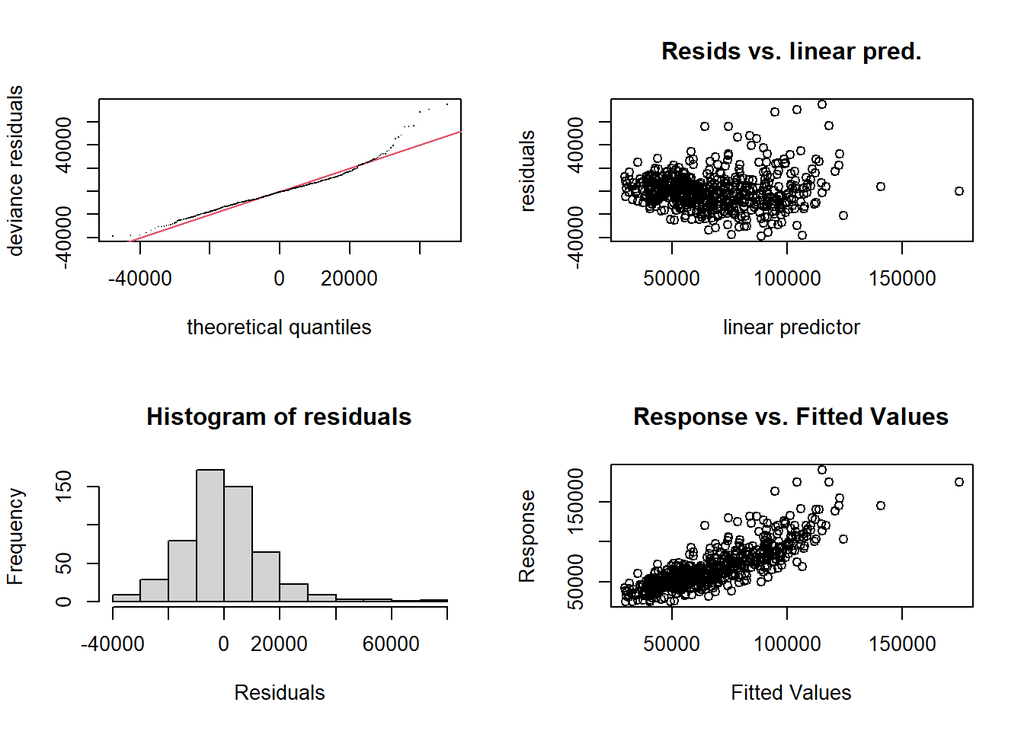

```
##
## Method: GCV   Optimizer: magic
## Smoothing parameter selection converged after 5 iterations.
## The RMS GCV score gradient at convergence was 84.05184 .
## The Hessian was positive definite.
## Model rank =  41 / 41
##
## Basis dimension (k) checking results. Low p-value (k-index<1) may
## indicate that k is too low, especially if edf is close to k'.
##
##               k'   edf k-index p-value
## s(lotsize) 26.00  3.22    0.95   0.095 .
## ---
## Signif. codes:  0 '***' 0.001 '**' 0.01 '*' 0.05 '.' 0.1 ' ' 1
```

```r
mgcv::gam.check(fitGaussAM)
```

From the residuals vs linear pred. plot, it can be seen that there is some heteroskadasticity because the variance tends to increase as we move towards the right. Histogram of residuals plot shows some skewness indicating that residuals are not normal. K-index < 1 for this model indicating that the value of k for s(lotsize) is low.P-value is 0.1.

### c. Obtain the Gamma GAM fit with the same response and predictors as used to obtain fitGaussAM in part a. This involves specifying family = Gamma in the call to gam(). Let fitGammaAM be the corresponding fit object

```r
fitGammaAM = mgcv::gam(price ~ s(lotsize,k = 27) + bedrooms + factor(bathrooms) + factor(stories) + factor(driveway) + factor(recreation) + factor(fullbase) + factor(gasheat) + factor(aircon) + garage + factor(prefer), data = HousePrices,family = Gamma)
summary(fitGammaAM)
```

```
##
## Family: Gamma
## Link function: inverse
##
## Formula:
## price ~ s(lotsize, k = 27) + bedrooms + factor(bathrooms) + factor(stories) +
##     factor(driveway) + factor(recreation) + factor(fullbase) +
##     factor(gasheat) + factor(aircon) + garage + factor(prefer)
##
## Parametric coefficients:
##                         Estimate Std. Error t value Pr(>|t|)
## (Intercept)            2.381e-05  8.087e-07  29.448  < 2e-16 ***
## bedrooms              -5.107e-07  2.236e-07  -2.284   0.0228 *
## factor(bathrooms)2    -2.223e-06  3.037e-07  -7.321 9.25e-13 ***
## factor(bathrooms)3    -3.306e-06  6.892e-07  -4.797 2.10e-06 ***
## factor(bathrooms)4    -3.656e-06  1.343e-06  -2.722   0.0067 **
## factor(stories)2      -1.542e-06  3.509e-07  -4.394 1.35e-05 ***
## factor(stories)3      -2.917e-06  5.264e-07  -5.542 4.72e-08 ***
## factor(stories)4      -3.084e-06  4.942e-07  -6.241 8.94e-10 ***
## factor(driveway)yes   -2.494e-06  5.497e-07  -4.538 7.04e-06 ***
## factor(recreation)yes -5.384e-07  3.274e-07  -1.644   0.1007
## factor(fullbase)yes   -1.669e-06  3.140e-07  -5.314 1.58e-07 ***
## factor(gasheat)yes    -2.512e-06  5.639e-07  -4.455 1.03e-05 ***
## factor(aircon)yes     -2.242e-06  2.977e-07  -7.530 2.22e-13 ***
## garage                -7.829e-07  1.589e-07  -4.927 1.12e-06 ***
## factor(prefer)yes     -1.381e-06  3.017e-07  -4.578 5.87e-06 ***
## ---
## Signif. codes:  0 '***' 0.001 '**' 0.01 '*' 0.05 '.' 0.1 ' ' 1
##
## Approximate significance of smooth terms:
##              edf Ref.df     F p-value
## s(lotsize) 3.907  4.933 25.12  <2e-16 ***
## ---
## Signif. codes:  0 '***' 0.001 '**' 0.01 '*' 0.05 '.' 0.1 ' ' 1
##
## R-sq.(adj) =  0.688   Deviance explained =   69%
## GCV = 0.046636  Scale est. = 0.045168  n = 546
```

### d. Issue the command gam.check(fitGammaAM) to check whether or not the residuals are consistent with the model assumptions

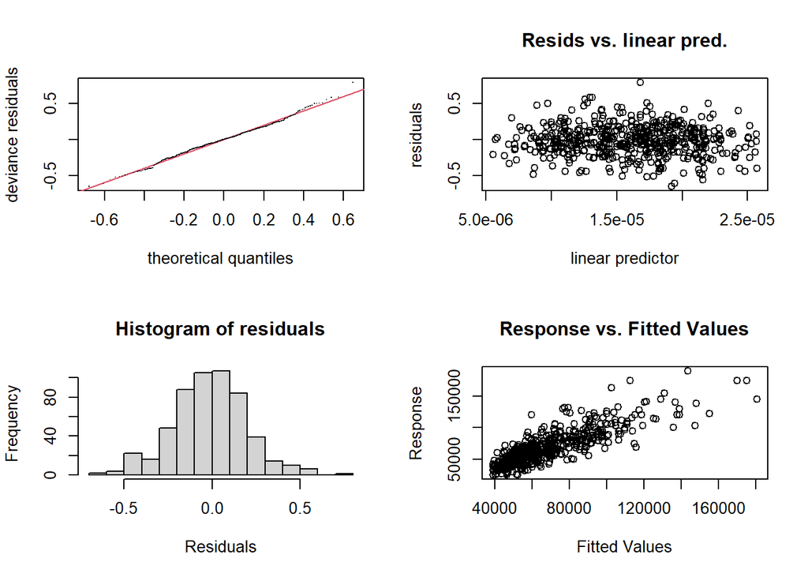

```
##
## Method: GCV   Optimizer: outer newton
## full convergence after 4 iterations.
## Gradient range [1.14479e-11,1.14479e-11]
## (score 0.04663558 & scale 0.04516827).
## Hessian positive definite, eigenvalue range [0.0001882159,0.0001882159].
## Model rank =  41 / 41
##
## Basis dimension (k) checking results. Low p-value (k-index<1) may
## indicate that k is too low, especially if edf is close to k'.
##
##               k'   edf k-index p-value
## s(lotsize) 26.00  3.91    0.99     0.4
```

```r
mgcv::gam.check(fitGammaAM)
```

## 2. For the AER data in Exercise 3.1, do the following: assume family=gaussian.

### a. A stepwise regression using gam::gam

```r
#It appears that if you have been playing around with code, that has called mgcv, you have to detach the package, or use gam::gam
if("package:mgcv" %in% search()) detach("package:mgcv", unload=TRUE)
library(gam)
```

```r
# Fit using all the variables as linear terms. This serves as a baseline.
# we do not use factor() on bedrooms and garage to match what is given in the textbook question 3.1a
fitGamGaussAM = gam::gam(price ~ lotsize + bedrooms + factor(bathrooms) + factor(stories) + factor(driveway) + factor(recreation) + factor(fullbase) + factor(gasheat) + factor(aircon) + garage + factor(prefer), data = HousePrices,family = gaussian)
summary(fitGamGaussAM)
```

```
##
## Call: gam::gam(formula = price ~ lotsize + bedrooms + factor(bathrooms) +
##     factor(stories) + factor(driveway) + factor(recreation) +
##     factor(fullbase) + factor(gasheat) + factor(aircon) + garage +
##     factor(prefer), family = gaussian, data = HousePrices)
## Deviance Residuals:
##      Min       1Q   Median       3Q      Max
## -40240.9  -9254.4   -829.1   7338.9  75424.0
##
## (Dispersion Parameter for gaussian family taken to be 238056589)
##
##     Null Deviance: 388602785841 on 545 degrees of freedom
## Residual Deviance: 1.2617e+11 on 530 degrees of freedom
## AIC: 12098.5
##
## Number of Local Scoring Iterations: 2
##
## Anova for Parametric Effects
##                     Df     Sum Sq    Mean Sq  F value    Pr(>F)
## lotsize              1 1.1156e+11 1.1156e+11 468.6235 < 2.2e-16 ***
## bedrooms             1 3.2329e+10 3.2329e+10 135.8029 < 2.2e-16 ***
## factor(bathrooms)    3 4.7182e+10 1.5727e+10  66.0648 < 2.2e-16 ***
## factor(stories)      3 1.8377e+10 6.1256e+09  25.7319 1.491e-15 ***
## factor(driveway)     1 6.9771e+09 6.9771e+09  29.3086 9.369e-08 ***
## factor(recreation)   1 6.7401e+09 6.7401e+09  28.3132 1.525e-07 ***
## factor(fullbase)     1 6.7128e+09 6.7128e+09  28.1985 1.614e-07 ***
## factor(gasheat)      1 2.0921e+09 2.0921e+09   8.7883  0.003168 **
## factor(aircon)       1 1.7352e+10 1.7352e+10  72.8890 < 2.2e-16 ***
## garage               1 5.7147e+09 5.7147e+09  24.0057 1.278e-06 ***
## factor(prefer)       1 7.3981e+09 7.3981e+09  31.0769 3.955e-08 ***
## Residuals          530 1.2617e+11 2.3806e+08
## ---
## Signif. codes:  0 '***' 0.001 '**' 0.01 '*' 0.05 '.' 0.1 ' ' 1
```

```r
#provide splines for continuous variables
StepfitGamGaussAM = step.Gam(fitGamGaussAM, scope=list(
                             "lotsize" = ~1 + lotsize + s(lotsize, df=4)
                             , "bedrooms" = ~1 + bedrooms
                             , "bathrooms" = ~ 1 + factor(bathrooms)
                             , "stories" = ~ 1 + factor(stories)
                             , "driveway" =  ~ 1 + factor(driveway)
                             , "recreation" =  ~ 1 + factor(recreation)
                             , "fullbase" = ~ 1 + factor(fullbase)
                             , "gasheat" = ~ 1 + factor(gasheat)
                             , "aircon" = ~ 1 + factor(aircon)
                             , "garage" = ~ 1 + garage
                             , "prefer" = ~ 1 + factor(prefer)
                            ),data = HousePrices,family = gaussian
                            )
```

```
## Start:  price ~ lotsize + bedrooms + factor(bathrooms) + factor(stories) +      factor(driveway) + factor(recreation) + factor(fullbase) +      factor(gasheat) + factor(aircon) + garage + factor(prefer); AIC= 12098.5
## Step:1 price ~ s(lotsize, df = 4) + bedrooms + factor(bathrooms) + factor(stories) +      factor(driveway) + factor(recreation) + factor(fullbase) +      factor(gasheat) + factor(aircon) + garage + factor(prefer) ; AIC= 12094.25
```

```r
print("Final Model from step.Gam is: ")
```

```
## [1] "Final Model from step.Gam is: "
```

```r
print(names(StepfitGamGaussAM$"model")[-1])
```

```
##  [1] "s(lotsize, df = 4)" "bedrooms"           "factor(bathrooms)"
##  [4] "factor(stories)"    "factor(driveway)"   "factor(recreation)"
##  [7] "factor(fullbase)"   "factor(gasheat)"    "factor(aircon)"
## [10] "garage"             "factor(prefer)"
```

### b. A variable selection regression using mgcv::gam using the select=TRUE option.

```r
if("package:gam" %in% search()) detach("package:gam", unload=TRUE)
library(mgcv)
```

```r
#From lecture notes, It looks like the select=TRUE option only penalizes spline terms
# we try splines for continuous variables
# we do not use factor() on bedrooms and garage to match what is given in the textbook question 3.1a
MgcvfitGamGaussAM = mgcv::gam(price ~ s(lotsize) + bedrooms + factor(bathrooms) + factor(stories) + factor(driveway) + factor(recreation) + factor(fullbase) + factor(gasheat) + factor(aircon) + garage + factor(prefer), data = HousePrices,family = gaussian, select = TRUE)
summary(MgcvfitGamGaussAM)
```

```
##
## Family: gaussian
## Link function: identity
##
## Formula:
## price ~ s(lotsize) + bedrooms + factor(bathrooms) + factor(stories) +
##     factor(driveway) + factor(recreation) + factor(fullbase) +
##     factor(gasheat) + factor(aircon) + garage + factor(prefer)
##
## Parametric coefficients:
##                       Estimate Std. Error t value Pr(>|t|)
## (Intercept)            35828.6     3550.2  10.092  < 2e-16 ***
## bedrooms                2103.3     1122.8   1.873 0.061587 .
## factor(bathrooms)2     13097.9     1735.0   7.549 1.94e-13 ***
## factor(bathrooms)3     29772.9     5107.4   5.829 9.70e-09 ***
## factor(bathrooms)4     68741.3    15757.9   4.362 1.55e-05 ***
## factor(stories)2        5712.2     1690.8   3.378 0.000783 ***
## factor(stories)3       12898.8     2903.8   4.442 1.09e-05 ***
## factor(stories)4       19731.6     3075.0   6.417 3.10e-10 ***
## factor(driveway)yes     5885.4     2074.1   2.838 0.004721 **
## factor(recreation)yes   3772.8     1926.6   1.958 0.050731 .
## factor(fullbase)yes     5842.3     1595.6   3.661 0.000276 ***
## factor(gasheat)yes     13022.1     3226.4   4.036 6.24e-05 ***
## factor(aircon)yes      11991.4     1582.7   7.576 1.60e-13 ***
## garage                  4097.6      852.6   4.806 2.01e-06 ***
## factor(prefer)yes       9709.1     1709.3   5.680 2.23e-08 ***
## ---
## Signif. codes:  0 '***' 0.001 '**' 0.01 '*' 0.05 '.' 0.1 ' ' 1
##
## Approximate significance of smooth terms:
##              edf Ref.df     F p-value
## s(lotsize) 3.164      9 11.33  <2e-16 ***
## ---
## Signif. codes:  0 '***' 0.001 '**' 0.01 '*' 0.05 '.' 0.1 ' ' 1
##
## R-sq.(adj) =   0.67   Deviance explained = 68.1%
## GCV = 2.4331e+08  Scale est. = 2.3522e+08  n = 546
```

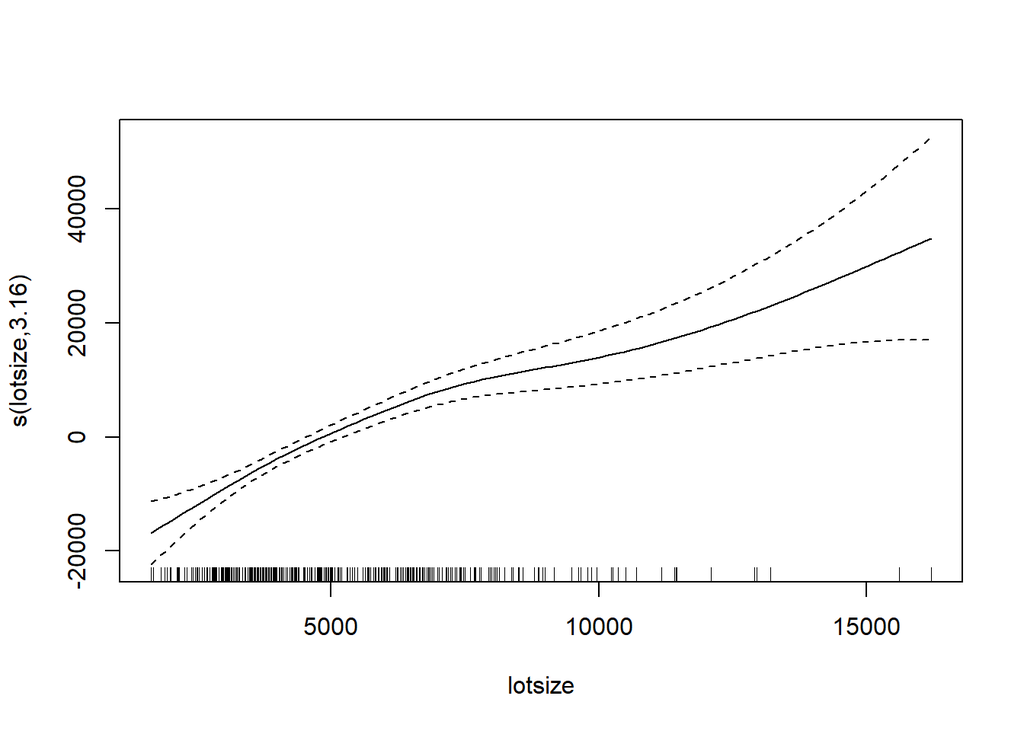

```r
plot(MgcvfitGamGaussAM)
```

### c. What variables overlap?

“s(lotsize)” “bedrooms” “factor(bathrooms)” “factor(stories)” “factor(driveway)” “factor(recreation)” “factor(fullbase)” “factor(gasheat)” “factor(aircon)” “garage” “factor(prefer)” overlap. Both Step.Gam and mgcv::gam select spline for lotsize.

## 3. Consider Exercise 3.3. You will be using the family=Gaussian command.

### a. First install the package gss, then type library(gss); data(ozone); pairs(ozone); help(ozone). Describe what you get from doing this. “ppm” is parts per million.

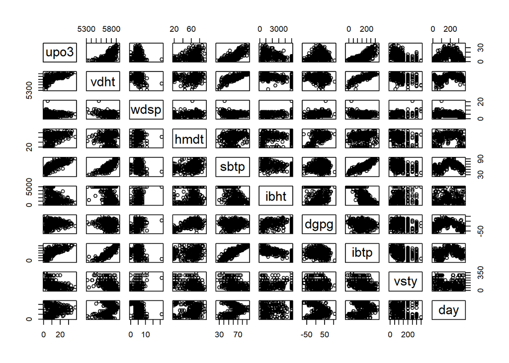

```r
library(gss)
data(ozone)
pairs(ozone)
```

```r
help(ozone)
```

```
## starting httpd help server ... done
```

This helps us to make the ozone data frame available to the current R session, visualize the data, and to show the variable names and their definitions.We see a matrix plot of scatterplots of different variable pairs.

### b. The response is upo3: what is it?

upo3 is “Upland ozone concentration, in ppm.”

### c. Do stepwise regression, including linear and spline forms for the continuous variables (which I think is all of them). What is the final model?

```r
#It appears that if you have been playing around with code, that has called mgcv, you have to detach the package, or use gam::gam
if("package:mgcv" %in% search()) detach("package:mgcv", unload=TRUE)
library(gam)
# Fit using all the variables as linear terms. This serves as a baseline
baselineFitOzoneGam = gam::gam(upo3 ~ ., data = ozone, family = gaussian)
summary(baselineFitOzoneGam)
```

```
##
## Call: gam::gam(formula = upo3 ~ ., family = gaussian, data = ozone)
## Deviance Residuals:
##      Min       1Q   Median       3Q      Max
## -12.2407  -2.8832  -0.3353   2.7409  13.3523
##
## (Dispersion Parameter for gaussian family taken to be 19.7225)
##
##     Null Deviance: 21115.41 on 329 degrees of freedom
## Residual Deviance: 6311.209 on 320 degrees of freedom
## AIC: 1932.326
##
## Number of Local Scoring Iterations: 2
##
## Anova for Parametric Effects
##            Df Sum Sq Mean Sq  F value    Pr(>F)
## vdht        1 7788.8  7788.8 394.9172 < 2.2e-16 ***
## wdsp        1  406.5   406.5  20.6130 7.969e-06 ***
## hmdt        1 3100.3  3100.3 157.1959 < 2.2e-16 ***
## sbtp        1 2415.2  2415.2 122.4578 < 2.2e-16 ***
## ibht        1  735.0   735.0  37.2678 2.978e-09 ***
## dgpg        1   12.5    12.5   0.6313  0.427464
## ibtp        1   76.4    76.4   3.8745  0.049888 *
## vsty        1   60.8    60.8   3.0810  0.080167 .
## day         1  208.8   208.8  10.5851  0.001262 **
## Residuals 320 6311.2    19.7
## ---
## Signif. codes:  0 '***' 0.001 '**' 0.01 '*' 0.05 '.' 0.1 ' ' 1
```

```r
#provide splines for continuous variables
StepFitOzoneGam = step.Gam(baselineFitOzoneGam, scope=list(
                             "vdht" = ~1 + vdht + s(vdht, df=4)
                             , "wdsp" = ~ 1 + wdsp + s(wdsp, df=4)
                             , "hmdt" = ~ 1 + hmdt + s(hmdt, df=4)
                             , "sbtp" =  ~ 1 + sbtp + s(sbtp, df=4)
                             , "ibht" =  ~ 1 + ibht + s(ibht, df=4)
                             , "dgpg" = ~ 1 + dgpg + s(dgpg, df=4)
                             , "ibtp" = ~ 1 + ibtp  + s(ibtp, df=4)
                             , "vsty" = ~ 1 + vsty + s(vsty, df=4)
                             , "day" = ~ 1 + day + s(day, df=4)
                            ),data = ozone,family = gaussian
                            )
```

```
## Start:  upo3 ~ .; AIC= 1932.326
## Step:1 upo3 ~ vdht + wdsp + hmdt + sbtp + ibht + dgpg + ibtp + vsty +      s(day, df = 4) ; AIC= 1891.072
## Step:2 upo3 ~ vdht + wdsp + hmdt + s(sbtp, df = 4) + ibht + dgpg + ibtp +      vsty + s(day, df = 4) ; AIC= 1848.685
## Step:3 upo3 ~ vdht + wdsp + hmdt + s(sbtp, df = 4) + ibht + s(dgpg,      df = 4) + ibtp + vsty + s(day, df = 4) ; AIC= 1820.346
## Step:4 upo3 ~ vdht + wdsp + hmdt + s(sbtp, df = 4) + ibht + s(dgpg,      df = 4) + ibtp + s(vsty, df = 4) + s(day, df = 4) ; AIC= 1816.347
## Step:5 upo3 ~ vdht + wdsp + hmdt + s(sbtp, df = 4) + s(dgpg, df = 4) +      ibtp + s(vsty, df = 4) + s(day, df = 4) ; AIC= 1814.31
```

```r
print("Final Model from Step.Gam is: ")
```

```
## [1] "Final Model from Step.Gam is: "
```

```r
print(names(StepFitOzoneGam$"model")[-1])
```

```
## [1] "vdht"            "wdsp"            "hmdt"            "s(sbtp, df = 4)"
## [5] "s(dgpg, df = 4)" "ibtp"            "s(vsty, df = 4)" "s(day, df = 4)"
```

### d. Now detach gam::gam and use using mgcv::gam to refit your model chosen in part c.

```r
if("package:gam" %in% search()) detach("package:gam", unload=TRUE)
library(mgcv)
MgcvFitOzoneFromStepWise = mgcv::gam(upo3 ~ vdht + wdsp + hmdt + s(sbtp) + s(dgpg) + ibtp  + s(vsty) + s(day), data=ozone, family = gaussian)
```

### e. Obtain numerical summaries from part d and interpret them

```r
summary(MgcvFitOzoneFromStepWise)
```

```
##
## Family: gaussian
## Link function: identity
##
## Formula:
## upo3 ~ vdht + wdsp + hmdt + s(sbtp) + s(dgpg) + ibtp + s(vsty) +
##     s(day)
##
## Parametric coefficients:
##               Estimate Std. Error t value Pr(>|t|)
## (Intercept) -84.264711  28.152989  -2.993  0.00298 **
## vdht          0.015811   0.004941   3.200  0.00152 **
## wdsp         -0.211178   0.104905  -2.013  0.04497 *
## hmdt          0.059428   0.017966   3.308  0.00105 **
## ibtp          0.016747   0.007422   2.256  0.02475 *
## ---
## Signif. codes:  0 '***' 0.001 '**' 0.01 '*' 0.05 '.' 0.1 ' ' 1
##
## Approximate significance of smooth terms:
##           edf Ref.df      F p-value
## s(sbtp) 5.310  6.448  8.501 < 2e-16 ***
## s(dgpg) 3.360  4.263 10.653 < 2e-16 ***
## s(vsty) 2.161  2.700  6.060 0.00084 ***
## s(day)  4.106  5.162 16.770 < 2e-16 ***
## ---
## Signif. codes:  0 '***' 0.001 '**' 0.01 '*' 0.05 '.' 0.1 ' ' 1
##
## R-sq.(adj) =  0.794   Deviance explained = 80.6%
## GCV = 14.087  Scale est. = 13.236    n = 330
```

### f. Now use the select=TRUE option and see what their final model is

```r
if("package:gam" %in% search()) detach("package:gam", unload=TRUE)
library(mgcv)
#From lecture notes, It looks like the select=TRUE option only penalizes spline terms
# we try splines for continuous variables
MgcvFitOzoneGam = mgcv::gam( upo3 ~ s(vdht) + s(wdsp) + s(hmdt) + s(sbtp) + s(ibht) + s(dgpg) + s(ibtp) + s(vsty) + s(day), data=ozone,   family = gaussian, select = TRUE)
summary(MgcvFitOzoneGam)
```

```
##
## Family: gaussian
## Link function: identity
##
## Formula:
## upo3 ~ s(vdht) + s(wdsp) + s(hmdt) + s(sbtp) + s(ibht) + s(dgpg) +
##     s(ibtp) + s(vsty) + s(day)
##
## Parametric coefficients:
##             Estimate Std. Error t value Pr(>|t|)
## (Intercept)  11.7758     0.1984   59.35   <2e-16 ***
## ---
## Signif. codes:  0 '***' 0.001 '**' 0.01 '*' 0.05 '.' 0.1 ' ' 1
##
## Approximate significance of smooth terms:
##           edf Ref.df     F  p-value
## s(vdht) 1.000      9 1.592 6.03e-05 ***
## s(wdsp) 1.071      9 0.405 0.030532 *
## s(hmdt) 1.574      9 1.183 0.000467 ***
## s(sbtp) 4.562      9 3.841  < 2e-16 ***
## s(ibht) 3.146      9 0.578 0.105567
## s(dgpg) 3.201      9 5.200  < 2e-16 ***
## s(ibtp) 1.372      9 0.364 0.052317 .
## s(vsty) 1.914      9 2.117 1.29e-05 ***
## s(day)  4.115      9 8.699  < 2e-16 ***
## ---
## Signif. codes:  0 '***' 0.001 '**' 0.01 '*' 0.05 '.' 0.1 ' ' 1
##
## R-sq.(adj) =  0.798   Deviance explained = 81.1%
## GCV = 13.962  Scale est. = 12.991    n = 330
```

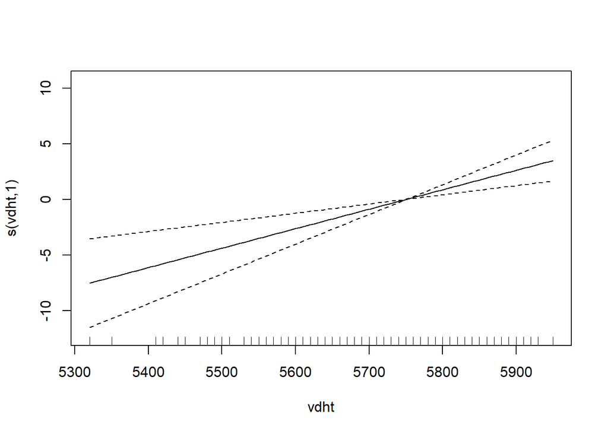

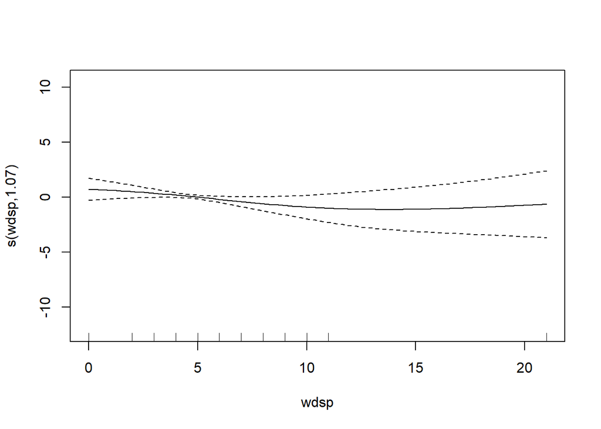

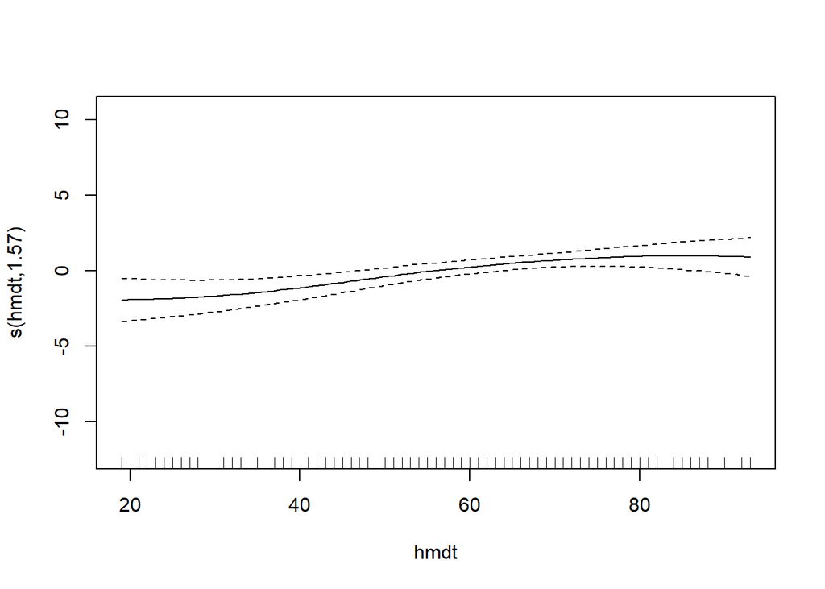

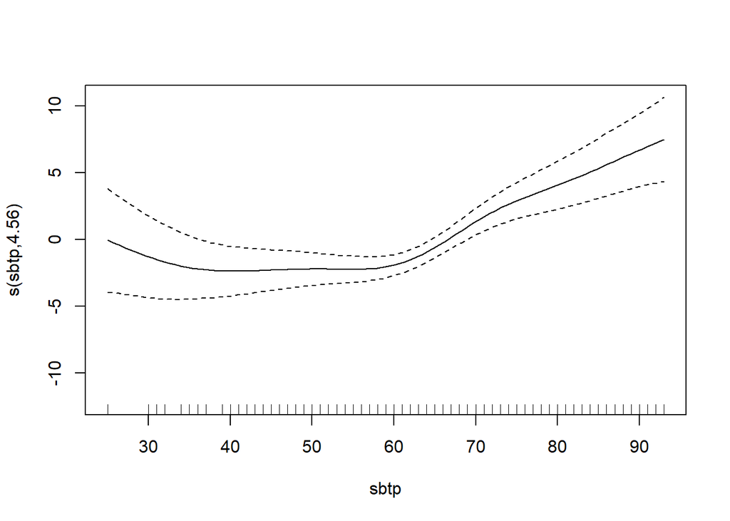

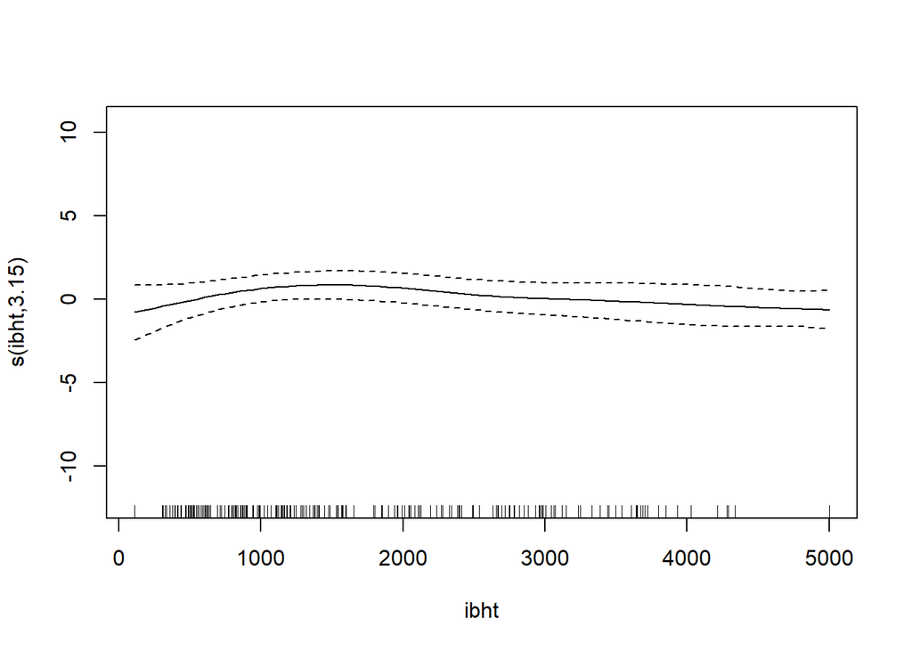

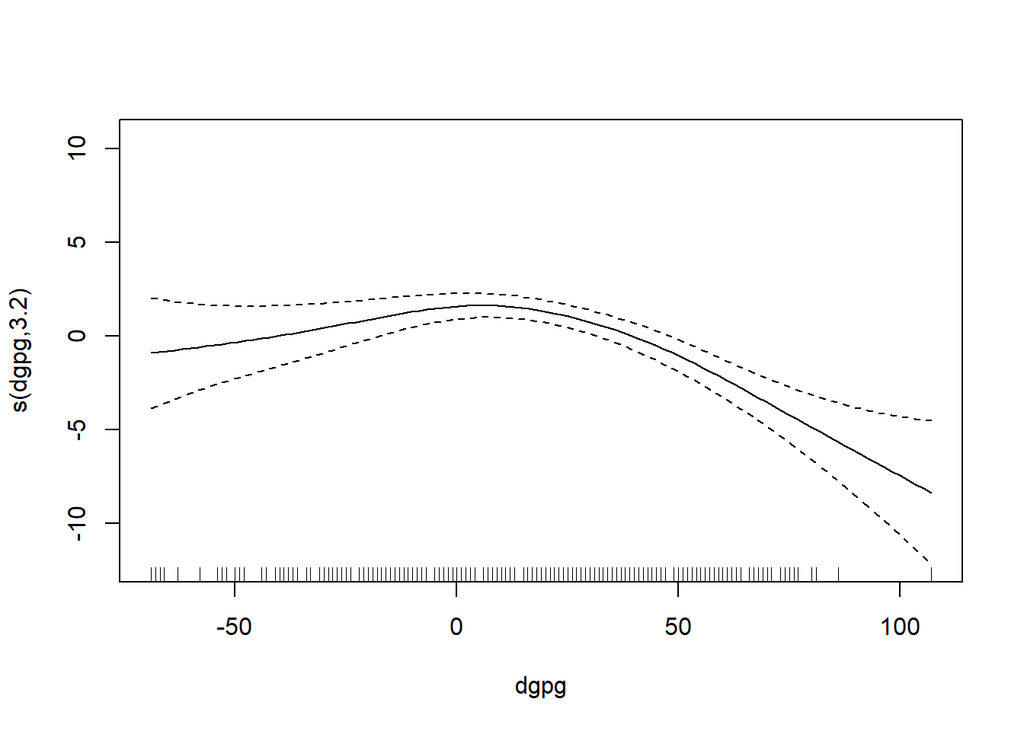

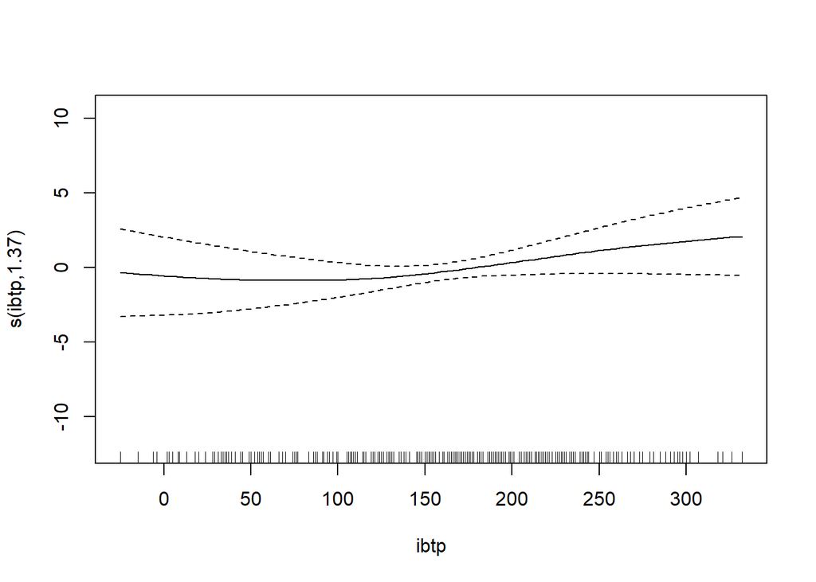

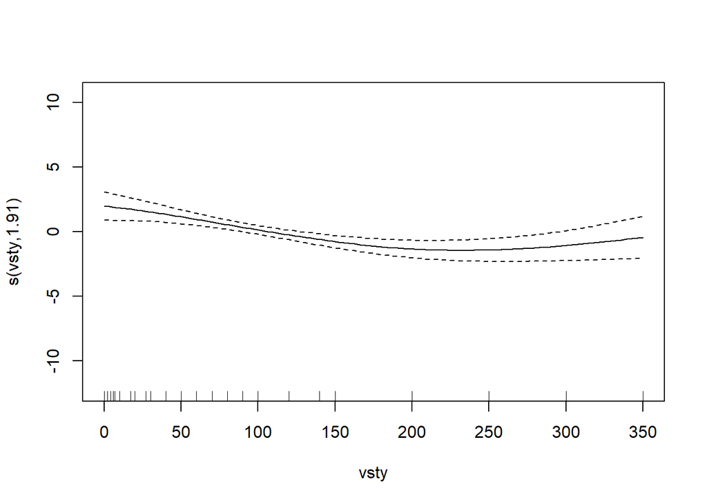

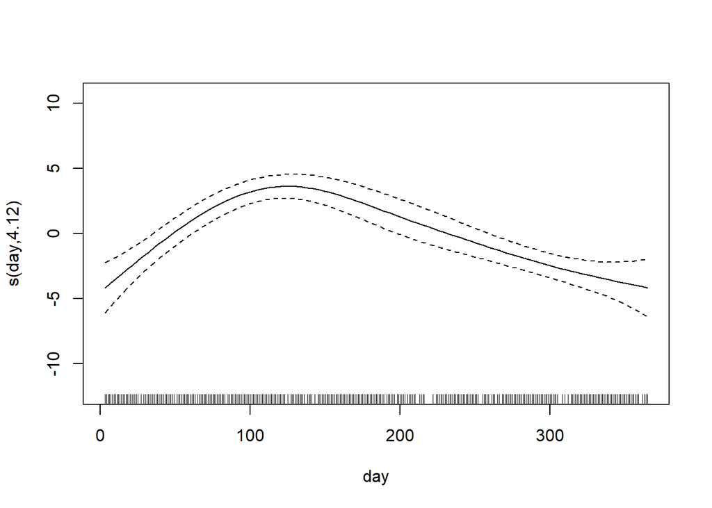

```r
plot(MgcvFitOzoneGam)
```

### g. Compare the two final models from stepwise regression and the mgcv method.

For mgcv with select=true, “wdsp”, “hmdt”, “ibht”, “ibpt” look close to horizontal in the plots and “vdht” looks linear too. s(ibht) and s(ibtp) are not statistically significant at 0.05 level.

step.Gam selects “vdht”, “wdsp”, “hmdt”, “s(sbtp, df = 4)”, “s(dgpg, df = 4)”, “ibtp”, “s(vsty, df = 4)”, “s(day, df = 4)” . It did not select ibht which wasn’t statistically significant for mgcv::gam. For step.Gam model, all terms were significant at 0.05 level.

### h. Do model selection using gamsel, if possible. Compare that model to the other selected models.

```r
library(gamsel)
upo3 <- ozone$upo3
X <- data.frame(ozone$vdht,ozone$wdsp,
                ozone$hmdt,ozone$sbtp,
                ozone$ibht,ozone$dgpg,
                ozone$ibtp, ozone$vsty,
                ozone$day)
fitCVgamsel <- cv.gamsel(X,y = upo3, family = c("gaussian"))
print(fitCVgamsel$gamsel.fit)
```

```
##
## Call:  gamsel(x = x, y = y, lambda = lambda, family = family, bases = bases)
##
##       NonZero Lin NonLin   %Dev  Lambda
##  [1,]       0   0      0 0.0000 283.600
##  [2,]       1   1      0 0.1044 258.200
##  [3,]       1   1      0 0.1910 235.000
##  [4,]       1   1      0 0.2627 213.900
##  [5,]       1   1      0 0.3221 194.700
##  [6,]       2   2      0 0.3738 177.300
##  [7,]       2   2      0 0.4176 161.400
##  [8,]       2   2      0 0.4538 146.900
##  [9,]       2   2      0 0.4839 133.700
## [10,]       2   2      0 0.5088 121.700
## [11,]       2   2      0 0.5294 110.800
```

[output cut: 39 more lines]

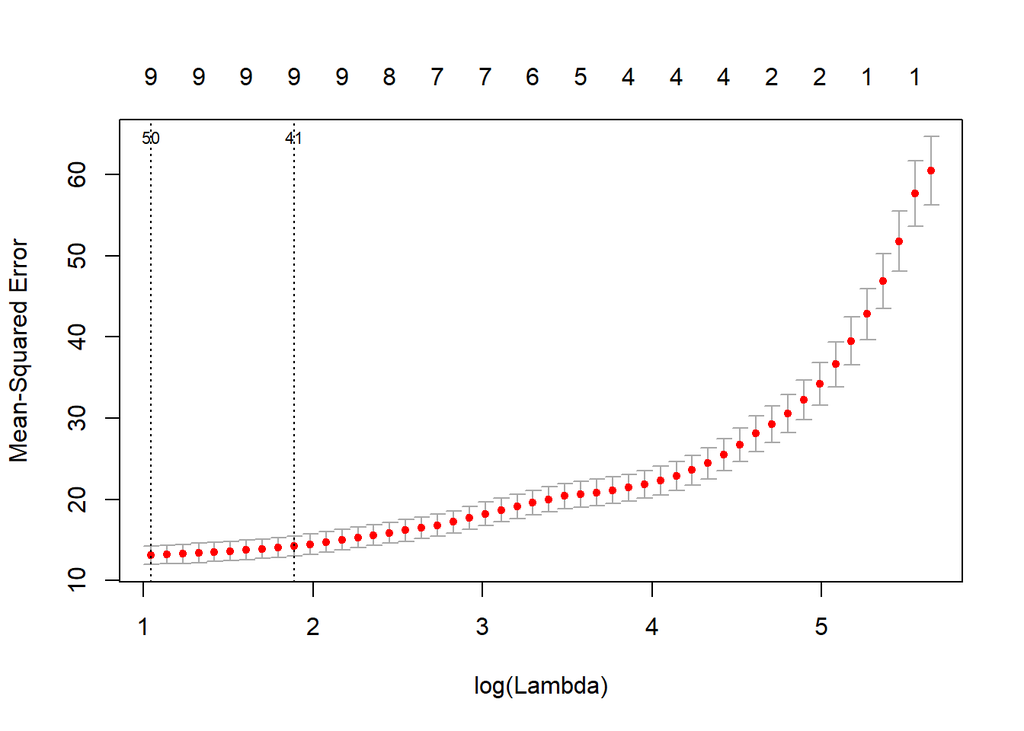

```r
par(mfrow=c(1,1))
plot(fitCVgamsel)
```

```r
#best model
fitCVgamsel$index.1se
```

```
## [1] 41
```

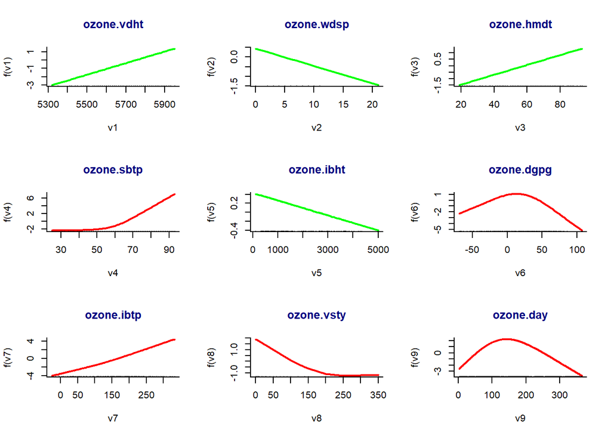

```r
par(mfrow = c(3,3))
for (iPred in 1:9){
  plot(fitCVgamsel$gamsel.fit,newx = X,which = iPred,
       index = fitCVgamsel$index.1se,col.main = "navy",
       main = names(X)[iPred],rugplot = TRUE,bty = "l")}
```

gamsel selects all variables. vdht, wdsp, hmdt and ibht are linear while others are non linear. In step.Gam, the linear terms were vdht, wdsp, hmdt and ibtp. Step.Gam did not select ibht. Mgcv:: gam had “wdsp”, “hmdt”, “ibht”, “ibpt” looking close to horizontal in the plots and “vdht” looking linear too.

We build a mgcv::gam model using the selection from gamsel and check the summary.

```r
if("package:gam" %in% search()) detach("package:gam", unload=TRUE)
library(mgcv)
MgcvFitOzoneFromGamsel = mgcv::gam(upo3 ~ vdht + wdsp + hmdt + s(sbtp) + ibht + s(dgpg) + ibtp  + s(vsty) + s(day), data=ozone, family = gaussian)
summary(MgcvFitOzoneFromGamsel)
```

```
##
## Family: gaussian
## Link function: identity
##
## Formula:
## upo3 ~ vdht + wdsp + hmdt + s(sbtp) + ibht + s(dgpg) + ibtp +
##     s(vsty) + s(day)
##
## Parametric coefficients:
##               Estimate Std. Error t value Pr(>|t|)
## (Intercept) -8.498e+01  2.839e+01  -2.993  0.00298 **
## vdht         1.597e-02  5.036e-03   3.172  0.00167 **
## wdsp        -2.094e-01  1.063e-01  -1.969  0.04980 *
## hmdt         5.912e-02  1.804e-02   3.278  0.00116 **
## ibht        -2.534e-05  2.604e-04  -0.097  0.92254
## ibtp         1.582e-02  1.186e-02   1.335  0.18300
## ---
## Signif. codes:  0 '***' 0.001 '**' 0.01 '*' 0.05 '.' 0.1 ' ' 1
##
## Approximate significance of smooth terms:
##           edf Ref.df      F  p-value
## s(sbtp) 5.293  6.429  8.032  < 2e-16 ***
## s(dgpg) 3.399  4.315 10.401  < 2e-16 ***
## s(vsty) 2.165  2.703  5.993 0.000905 ***
## s(day)  4.118  5.180 15.918  < 2e-16 ***
## ---
## Signif. codes:  0 '***' 0.001 '**' 0.01 '*' 0.05 '.' 0.1 ' ' 1
##
## R-sq.(adj) =  0.793   Deviance explained = 80.6%
## GCV = 14.179  Scale est. = 13.278    n = 330
```

ibht and ibtp are not statistically significant at 0.05 level in the above summary. All other predictors are statistically significant at 0.05 level. For mgcv with select=true, s(ibht) and s(ibtp) are not statistically significant at 0.05 level. This matches with what is seen in the gamsel model. Step.Gam did not select ibht but all other terms were statistically significant at 0.05 level.

## 4. Consider Exercise 3.4. You will be using the family=logistic command.

### a. Issue the following commands to load and obtain a listing of the variables in the data frame icu: > library(aplore3) ; data(icu) ; help(icu) The data frame consists of 21 variables for 200 patients admitted to an intensive care unit (ICU).

```r
library(aplore3)
data(icu)
help(icu)
```

### b. Use the function step.Gam() in the gam package to select a logistic GAM with the response variable being the indicator of the patient dying.

```r
icu$live <- ifelse(icu$sta=="Lived", 1, 0)
#It appears that if you have been playing around with code, that has called mgcv, you have to detach the package, or use gam::gam
if("package:mgcv" %in% search()) detach("package:mgcv", unload=TRUE)
library(gam)
#do not use splines for continuous terms in baseline
icubaselinegam = gam::gam(live ~ age + factor(gender) + factor(race) + factor(ser) +
                            factor(can) + factor(crn) + factor(inf) + factor(cpr) + sys + hra +
                            factor(pre)  + factor(type) + factor(fra) + factor(po2) + factor(ph) + factor(pco) + factor(bic) + factor(cre)
                          + factor(loc), data=icu, family=binomial(link="logit"))
stepicugam = gam::step.Gam(icubaselinegam, scope=
                          list("age" = ~ 1 + age + s(age, 2)
                               ,"age" = ~ 1 + age + s(age, 3)
                               ,"age" = ~ 1 + age + s(age, 4)
                               , "gender" = ~ 1 + factor(gender)
                               , "race" = ~1 + factor(race)
                               , "ser" = ~ 1 + factor(ser)
                               , "can" = ~ 1 + factor(can)
                               , "crn" = ~ 1 + factor(crn)
                               , "inf" = ~ 1 + factor(inf)
                               , "cpr" = ~ 1 + factor(cpr)
                               , "sys" = ~ 1 + sys + s(sys, 2)
                               , "sys" = ~ 1 + sys + s(sys, 3)
                               , "sys" = ~ 1 + sys + s(sys, 4)
                               , "hra" = ~ 1 + hra + s(hra, 2)
                               , "hra" = ~ 1 + hra + s(hra, 3)
                               , "hra" = ~ 1 + hra + s(hra, 4)
                               , "pre" = ~ 1 + factor(pre)
                               , "type" = ~ 1 + factor(type)
                               , "fra" = ~ 1 + factor(fra)
                               , "po2" = ~ 1 +factor(po2)
                               , "ph" = ~ 1 + factor(ph)
                               , "pco" = ~ 1 + factor(pco)
                               , "bic" = ~ 1 + factor(bic)
                               , "cre" = ~ 1 + factor(cre)
                               , "loc" = ~ 1 + factor(loc)
                               )
                           , data=icu, family=binomial(link="logit")
                           )
```

```
## Start:  live ~ age + factor(gender) + factor(race) + factor(ser) + factor(can) +      factor(crn) + factor(inf) + factor(cpr) + sys + hra + factor(pre) +      factor(type) + factor(fra) + factor(po2) + factor(ph) + factor(pco) +      factor(bic) + factor(cre) + factor(loc); AIC= 156.1673
## Step:1 live ~ age + factor(gender) + factor(race) + factor(ser) + factor(can) +      factor(crn) + factor(inf) + factor(cpr) + sys + hra + factor(pre) +      factor(type) + factor(fra) + factor(po2) + factor(ph) + factor(pco) +      factor(bic) + factor(loc) ; AIC= 154.1751
## Step:2 live ~ age + factor(gender) + factor(race) + factor(ser) + factor(can) +      factor(inf) + factor(cpr) + sys + hra + factor(pre) + factor(type) +      factor(fra) + factor(po2) + factor(ph) + factor(pco) + factor(bic) +      factor(loc) ; AIC= 152.2039
## Step:3 live ~ age + factor(gender) + factor(race) + factor(ser) + factor(can) +      factor(cpr) + sys + hra + factor(pre) + factor(type) + factor(fra) +      factor(po2) + factor(ph) + factor(pco) + factor(bic) + factor(loc) ; AIC= 150.2378
## Step:4 live ~ age + factor(gender) + factor(race) + factor(ser) + factor(can) +      factor(cpr) + sys + hra + factor(pre) + factor(type) + factor(fra) +      factor(po2) + factor(ph) + factor(pco) + factor(loc) ; AIC= 148.3229
## Step:5 live ~ age + factor(gender) + factor(race) + factor(ser) + factor(can) +      factor(cpr) + sys + factor(pre) + factor(type) + factor(fra) +      factor(po2) + factor(ph) + factor(pco) + factor(loc) ; AIC= 146.4179
## Step:6 live ~ age + factor(gender) + factor(race) + factor(ser) + factor(can) +      factor(cpr) + sys + factor(pre) + factor(type) + factor(fra) +      factor(ph) + factor(pco) + factor(loc) ; AIC= 145.1324
## Step:7 live ~ age + factor(gender) + factor(race) + factor(can) + factor(cpr) +      sys + factor(pre) + factor(type) + factor(fra) + factor(ph) +      factor(pco) + factor(loc) ; AIC= 143.8712
## Step:8 live ~ age + factor(gender) + factor(can) + factor(cpr) + sys +      factor(pre) + factor(type) + factor(fra) + factor(ph) + factor(pco) +      factor(loc) ; AIC= 143.2064
## Step:9 live ~ age + factor(gender) + factor(can) + factor(cpr) + sys +      factor(pre) + factor(type) + factor(ph) + factor(pco) + factor(loc) ; AIC= 142.4638
## Step:10 live ~ s(age, 2) + factor(gender) + factor(can) + factor(cpr) +      sys + factor(pre) + factor(type) + factor(ph) + factor(pco) +      factor(loc) ; AIC= 141.744
```

```r
#print final model
print("Final model is: ")
```

```
## [1] "Final model is: "
```

```r
print(names(stepicugam$"model")[-1])
```

```
##  [1] "s(age, 2)"      "factor(gender)" "factor(can)"    "factor(cpr)"
##  [5] "sys"            "factor(pre)"    "factor(type)"   "factor(ph)"
##  [9] "factor(pco)"    "factor(loc)"
```

### c. Use the function gam() in the mgcv package to re-fit the model selected in part b. with GCV used for selection of the smoothing parameters of the penalized spline components of the model. Obtain numerical and graphical summaries of the selected model.

```r
if("package:gam" %in% search()) detach("package:gam", unload=TRUE)
library(mgcv)
mgcvicugamstep = mgcv::gam(live ~ s(age) + factor(gender) + factor(can) + factor(cpr) + sys + factor(pre) + factor(type) + factor(ph) + factor(pco) + factor(loc), data=icu, family=binomial(link="logit"))
summary(mgcvicugamstep)
```

```
##
## Family: binomial
## Link function: logit
##
## Formula:
## live ~ s(age) + factor(gender) + factor(can) + factor(cpr) +
##     sys + factor(pre) + factor(type) + factor(ph) + factor(pco) +
##     factor(loc)
##
## Parametric coefficients:
##                         Estimate Std. Error z value Pr(>|z|)
## (Intercept)            3.181e+00  1.562e+00   2.037  0.04165 *
## factor(gender)Female   7.100e-01  5.201e-01   1.365  0.17219
## factor(can)Yes        -3.316e+00  1.045e+00  -3.174  0.00151 **
## factor(cpr)Yes        -1.207e+00  8.596e-01  -1.404  0.16041
## sys                    1.970e-02  8.178e-03   2.408  0.01602 *
## factor(pre)Yes        -1.044e+00  6.408e-01  -1.630  0.10315
## factor(type)Emergency -3.948e+00  1.290e+00  -3.060  0.00221 **
## factor(ph)< 7.25      -1.835e+00  9.716e-01  -1.889  0.05888 .
## factor(pco)> 45        2.092e+00  9.967e-01   2.099  0.03582 *
## factor(loc)Stupor     -3.405e+01  5.860e+05   0.000  0.99995
## factor(loc)Coma       -3.286e+00  1.129e+00  -2.911  0.00360 **
## ---
## Signif. codes:  0 '***' 0.001 '**' 0.01 '*' 0.05 '.' 0.1 ' ' 1
##
## Approximate significance of smooth terms:
##          edf Ref.df Chi.sq p-value
## s(age) 1.715  2.144  12.94  0.0019 **
## ---
## Signif. codes:  0 '***' 0.001 '**' 0.01 '*' 0.05 '.' 0.1 ' ' 1
##
## R-sq.(adj) =  0.418   Deviance explained =   42%
## UBRE = -0.2921  Scale est. = 1         n = 200
```

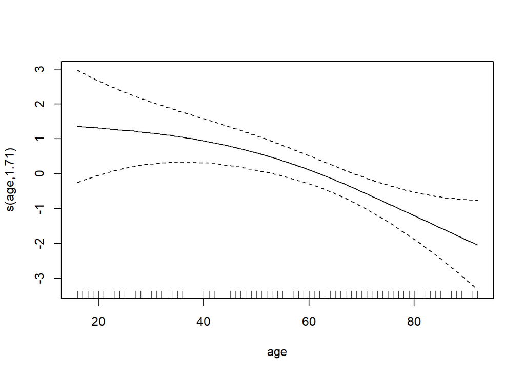

```r
plot(mgcvicugamstep)
```

### d. Consider a 79-year-old white woman who enters the ICU as an emergency patient in a coma. The woman has no history of previous ICU admission, cancer, chronic renal failure, and is free of infection at the time of admission. Cardiopulmonary resuscitation is not needed and she has no fractures. Finally, at the time of admission she has the following medical measurements (given in code). Estimate the woman’s survival probability.

```r
new_patient = data.frame(
    age=79
    , gender="Female"
    , race="White"
    , ser="Medical"
    , can="No"
    , crn="No"
    , inf="No"
    , cpr="No"
    , sys=228
    , hra=94
    , pre="No"
    , type="Emergency"
    , fra="No"
    , po2="<= 60"
    , ph=">= 7.25"
    , pco="> 45"
    , bic="< 18"
    , cre="> 2.0"
    , loc="Coma"
)
new_patient_pred <- mgcv::predict.gam(mgcvicugamstep, newdata=new_patient, type="response")
print("survival probability of the woman given by:")
```

```
## [1] "survival probability of the woman given by:"
```

```r
print(new_patient_pred)
```

```
##         1
## 0.8911357
```

### e. Use the select=TRUE option in mgcv::gam to do model selection. Compare the model with that in 4b above. Comment on what happens.

```r
#From lecture notes, It looks like the select=TRUE option only penalizes spline terms
mgcvicuselect =  mgcv::gam(live ~ s(age) + factor(gender) + factor(race) + factor(ser) +
                            factor(can) + factor(crn) + factor(inf) + factor(cpr) + s(sys) + s(hra) +
                            factor(pre)  + factor(type) + factor(fra) + factor(po2) + factor(ph) + factor(pco) + factor(bic) + factor(cre)
                          + factor(loc), data=icu, family=binomial(link="logit"), select = TRUE)
summary(mgcvicuselect)
```

```
##
## Family: binomial
## Link function: logit
##
## Formula:
## live ~ s(age) + factor(gender) + factor(race) + factor(ser) +
##     factor(can) + factor(crn) + factor(inf) + factor(cpr) + s(sys) +
##     s(hra) + factor(pre) + factor(type) + factor(fra) + factor(po2) +
##     factor(ph) + factor(pco) + factor(bic) + factor(cre) + factor(loc)
##
## Parametric coefficients:
##                         Estimate Std. Error z value Pr(>|z|)
## (Intercept)            5.019e+00  1.462e+00   3.433 0.000598 ***
## factor(gender)Female   6.495e-01  5.567e-01   1.167 0.243396
## factor(race)Black      5.379e+01  1.744e+07   0.000 0.999998
## factor(race)Other     -2.099e-01  1.287e+00  -0.163 0.870451
## factor(ser)Surgical    9.756e-01  6.600e-01   1.478 0.139339
## factor(can)Yes        -3.643e+00  1.137e+00  -3.204 0.001357 **
## factor(crn)Yes        -4.771e-02  8.949e-01  -0.053 0.957477
## factor(inf)Yes         1.597e-01  5.663e-01   0.282 0.777916
## factor(cpr)Yes        -9.526e-01  1.076e+00  -0.885 0.376106
## factor(pre)Yes        -1.526e+00  7.240e-01  -2.108 0.034998 *
## factor(type)Emergency -3.550e+00  1.353e+00  -2.623 0.008711 **
## factor(fra)Yes        -1.374e+00  1.066e+00  -1.289 0.197335
## factor(po2)<= 60       5.232e-01  9.599e-01   0.545 0.585759
## factor(ph)< 7.25      -1.740e+00  1.257e+00  -1.384 0.166220
## factor(pco)> 45        2.292e+00  1.233e+00   1.859 0.063017 .
## factor(bic)< 18        3.326e-01  9.157e-01   0.363 0.716470
## factor(cre)> 2.0      -1.331e-01  1.240e+00  -0.107 0.914481
## factor(loc)Stupor     -9.807e+01  3.021e+07   0.000 0.999997
## factor(loc)Coma       -3.985e+00  1.431e+00  -2.786 0.005343 **
## ---
## Signif. codes:  0 '***' 0.001 '**' 0.01 '*' 0.05 '.' 0.1 ' ' 1
##
## Approximate significance of smooth terms:
##              edf Ref.df Chi.sq  p-value
## s(age) 1.785e+00      9 11.486 0.000748 ***
## s(sys) 3.448e+00      9  7.081 0.072196 .
## s(hra) 5.874e-05      9  0.000 0.709126
## ---
## Signif. codes:  0 '***' 0.001 '**' 0.01 '*' 0.05 '.' 0.1 ' ' 1
##
## R-sq.(adj) =  0.424   Deviance explained = 47.8%
## UBRE = -0.23516  Scale est. = 1         n = 200
```

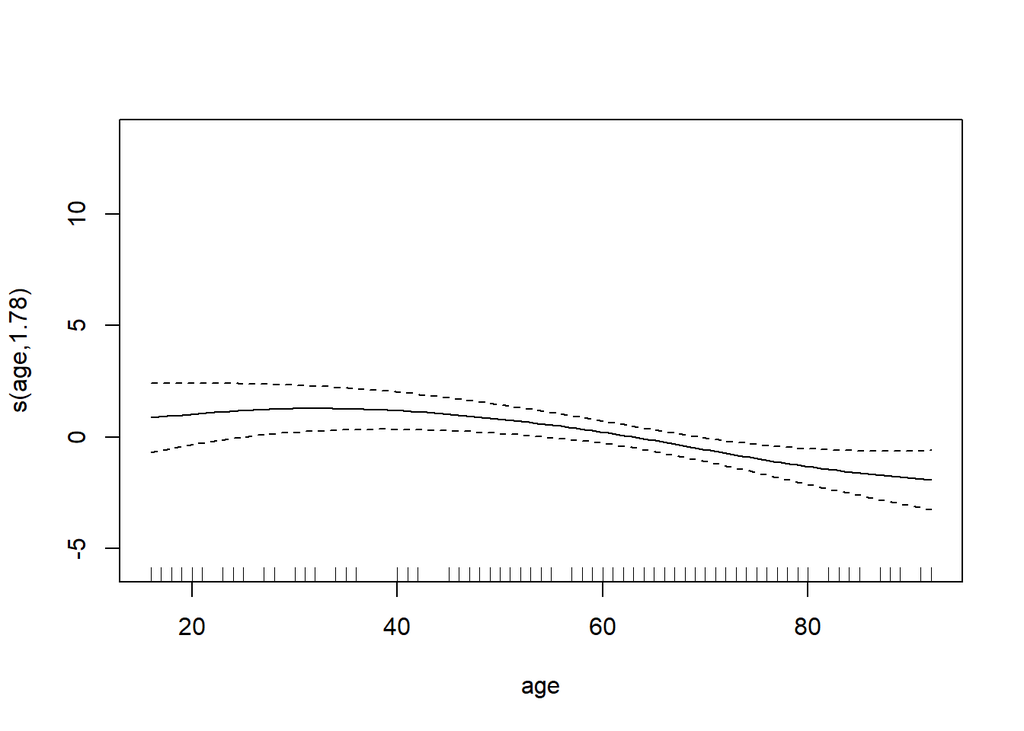

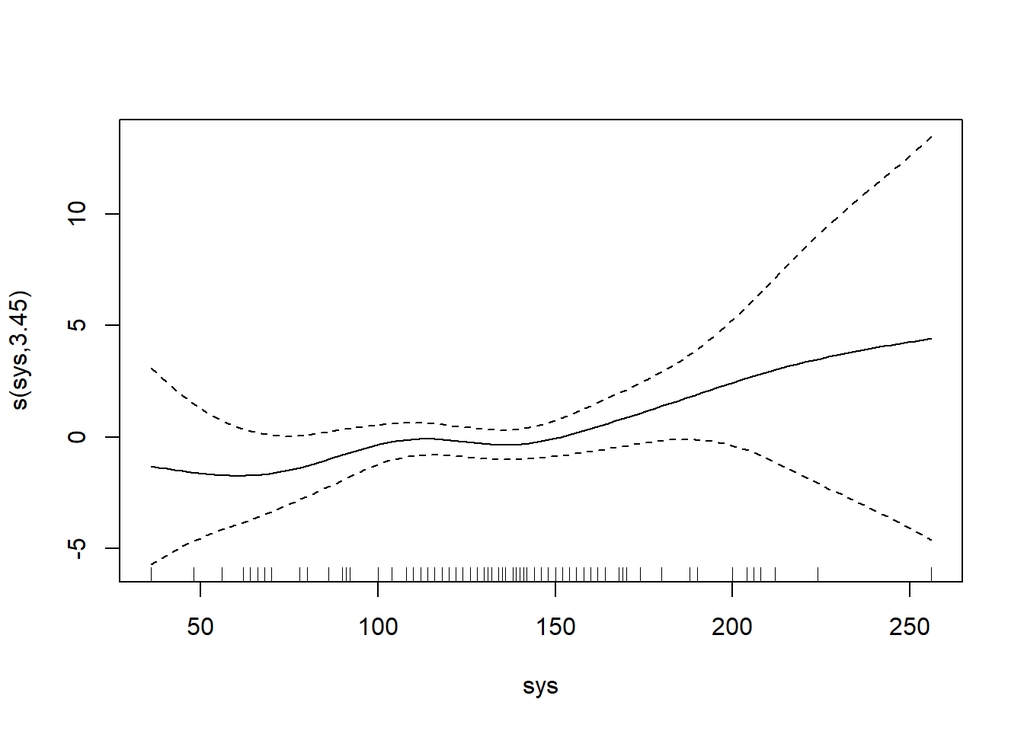

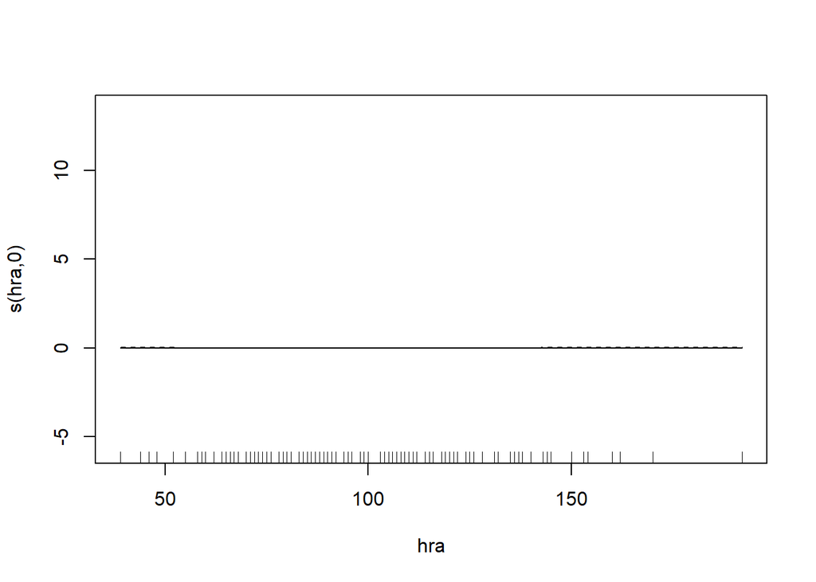

```r
plot(mgcvicuselect)
```

mgcv::gam with select=true does not select hra like step.Gam (see the horizontal line in the hra plot, it ‘shrinks’ to zero) but it selects age and sys splines as per the plots. In the model selected by mgcv::gam, s(sys) is not statistically significant at 0.05 level whereas sys was statistically significant for the model selected by step.Gam at level 0.05. mgcv::gam does not do penalization on linear terms.